# Statistics 744, McMaster University

# Exploratory visualization

Jonathan Dushoff

September 2021

## Exploring data

### Rote analysis vs. snooping

[figure not shown]

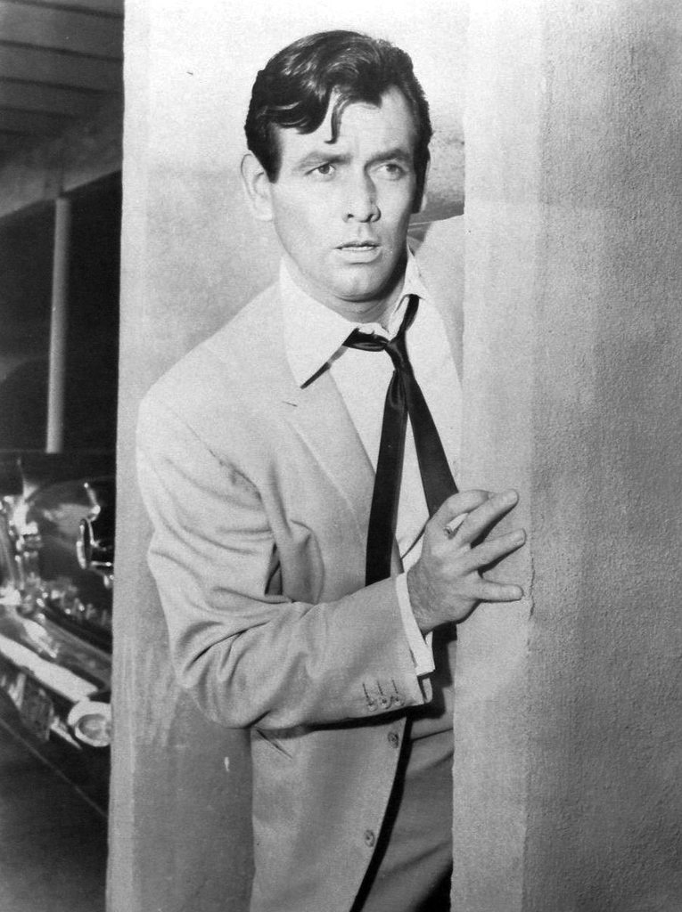

## Spurious correlations

[There’s a whole website about this](http://www.tylervigen.com/spurious-correlations)

## What can you do?

### The best you can

- Identify scientific questions
- Distinguish between exploratory and confirmatory analysis
- Pre-register studies when possible
- Keep an exploration and analysis journal
- Explore predictors and responses separately at first

# Individual variables

## Individual variables

- Look at location and shape
- Maybe with different sets of grouping variables
- Contrasts
  - Parametric vs. non-parametric
  - Exploratory vs. diagnostic
  - Data vs. inference

## Means and standard errors

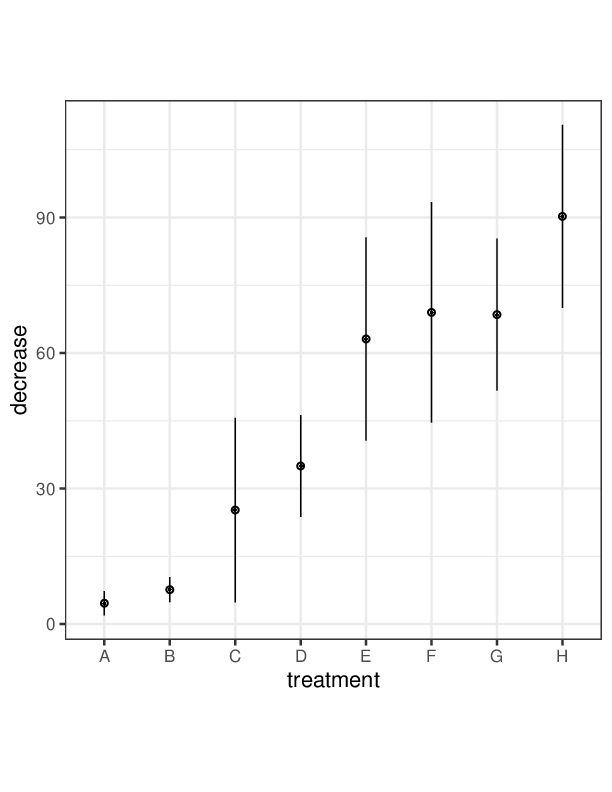

## Means and standard deviations

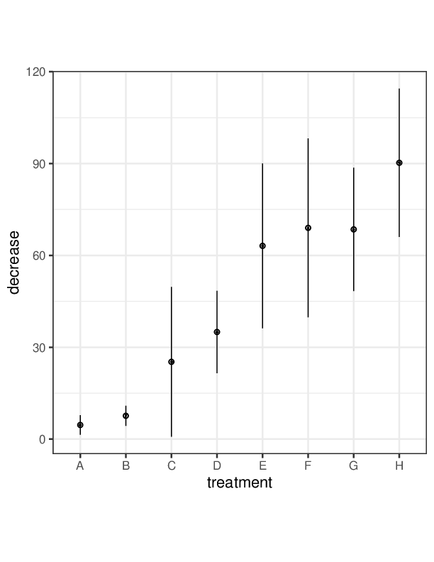

## Means and standard deviations

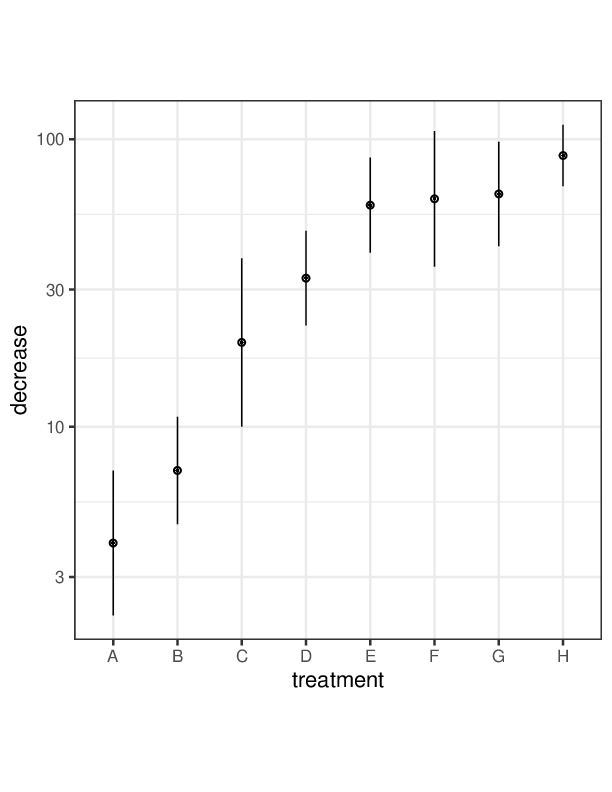

### Next steps?

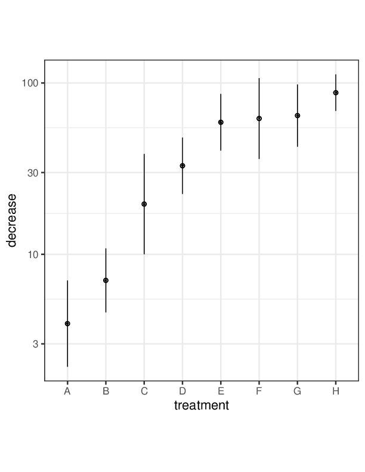

## Non-parametric

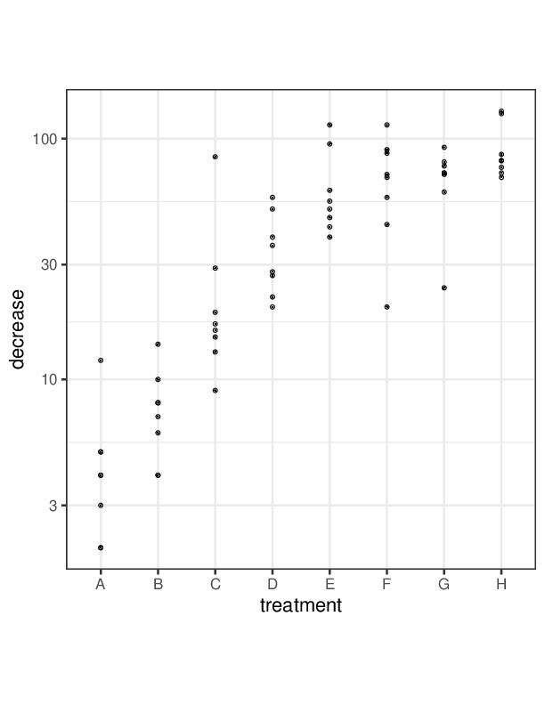

## Non-parametric

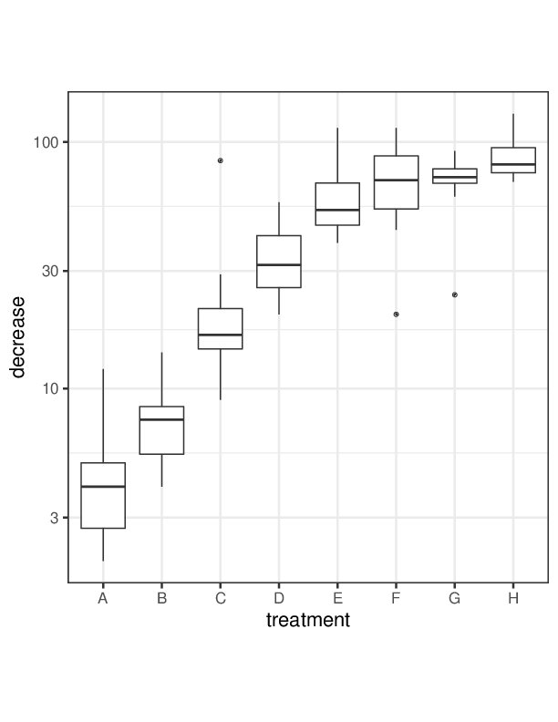

## Non-parametric

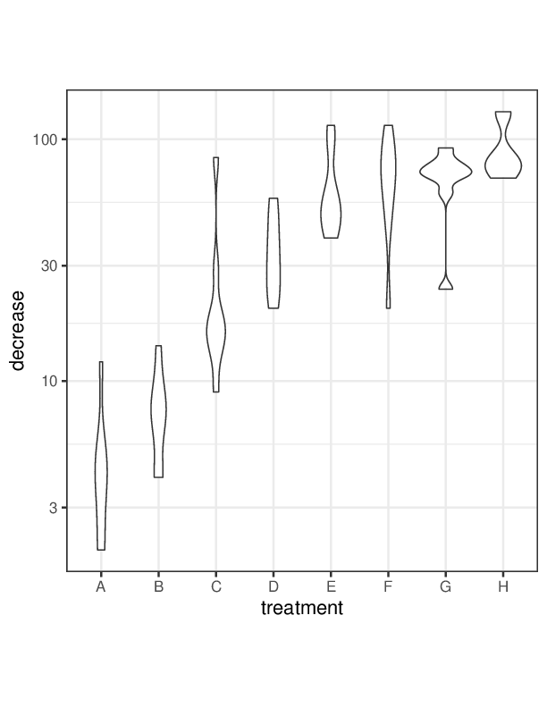

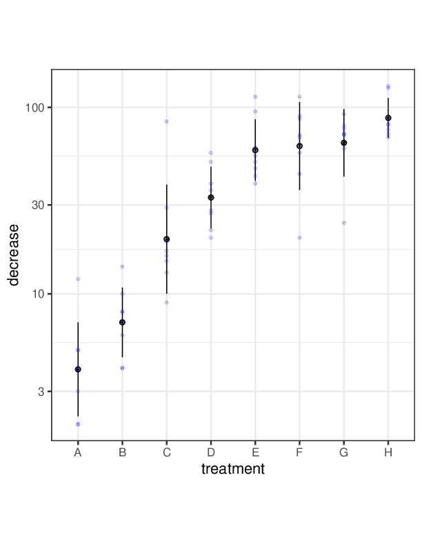

## Bike example

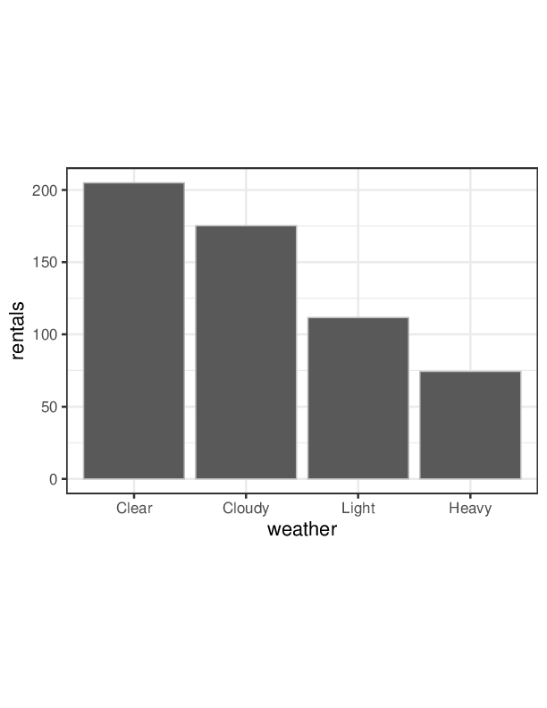

## Standard errors

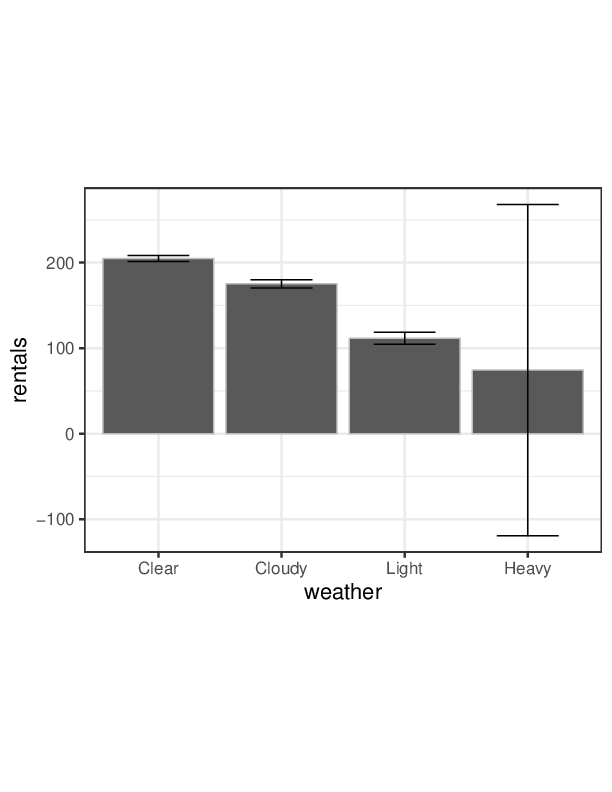

## Standard errors

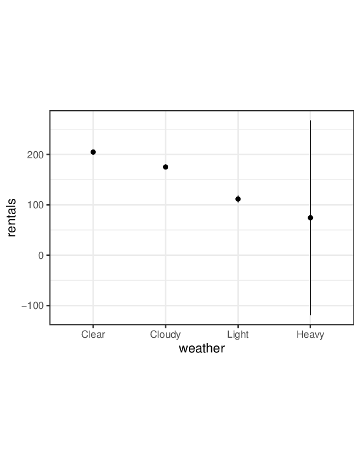

## Standard deviations (2 sd, in fact)

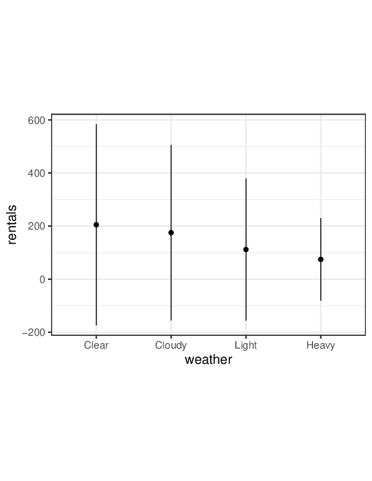

## Data shape

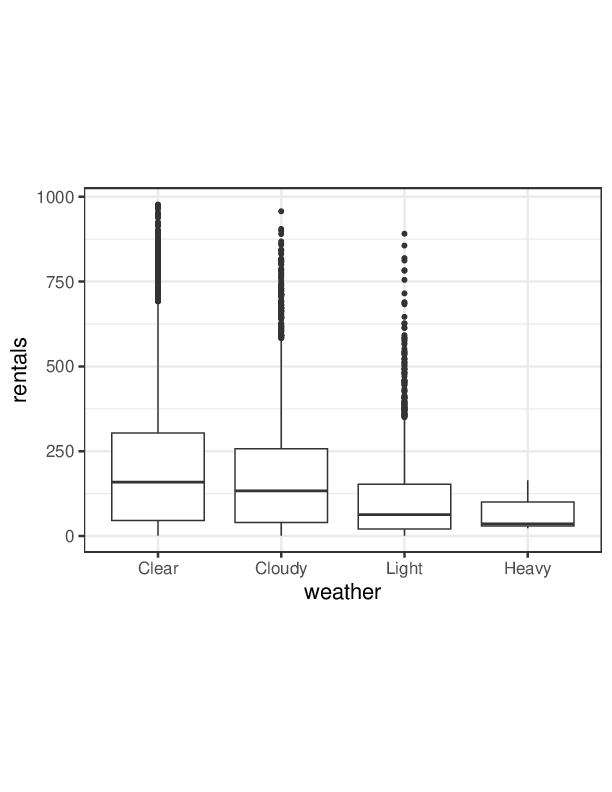

## Data shape

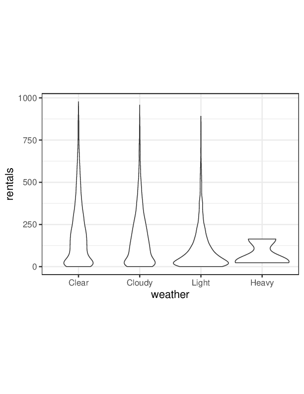

## Data shape

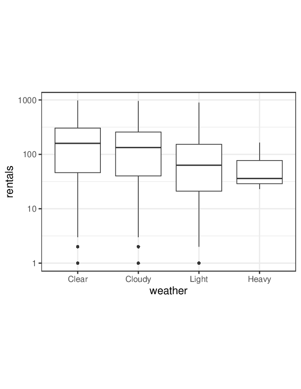

## Data shape

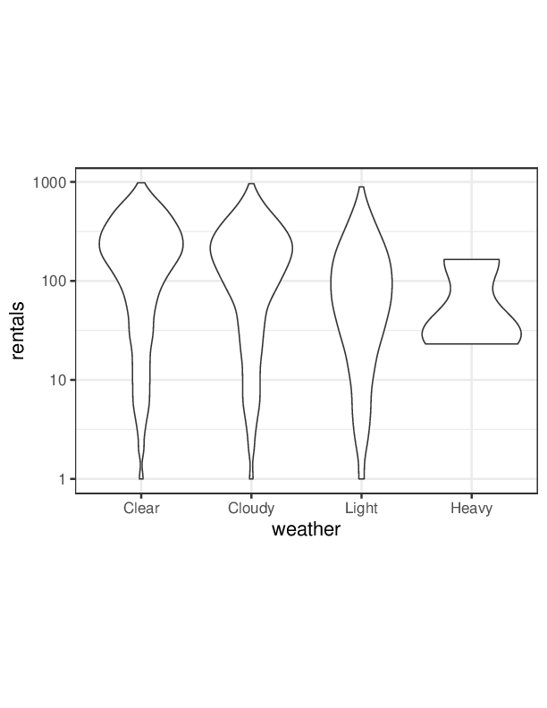

## Shape and weight

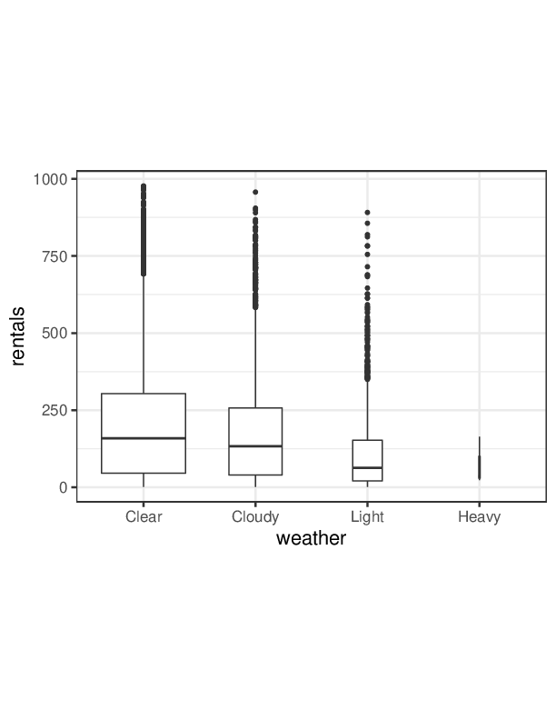

## Shape and weight

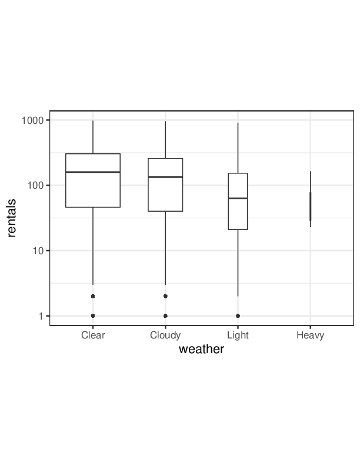

## Log scales

- In general:
  - If your logged data span < 3 decades, use human-readable numbers (e.g., 10-5000 kilotons per hectare)
  - If not, just embrace ``logs’’ (log10 particles per ul is from 3–8)
    - But remember these are not physical values
- I love natural logs, but not as axis values
  - Except to represent proportional difference!

# Bivariate data

## Banking

- Banking is a real thing
  - Even though many examples are bogus
- Since the point is to make patterns visually clear, trial-and-error is usually as good as algorithm

## Smoking data

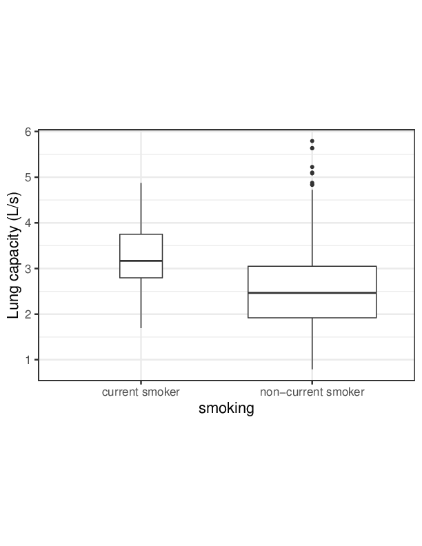

## Smoking data

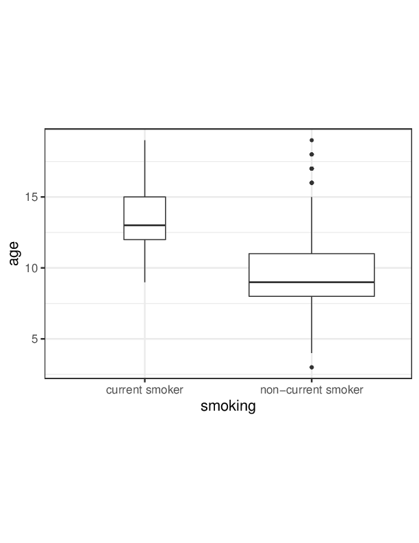

## Scatter plots

- Depending on how many data points you have, scatter plots may indicate relationships clearly
- They can often be improved with trend interpolations
  - Interpolations may be particularly good for discrete responses (count or true-false)

## Scatter plot

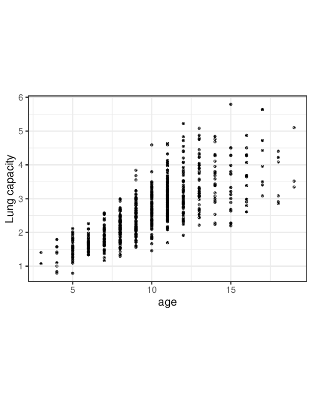

## Seeing the density better

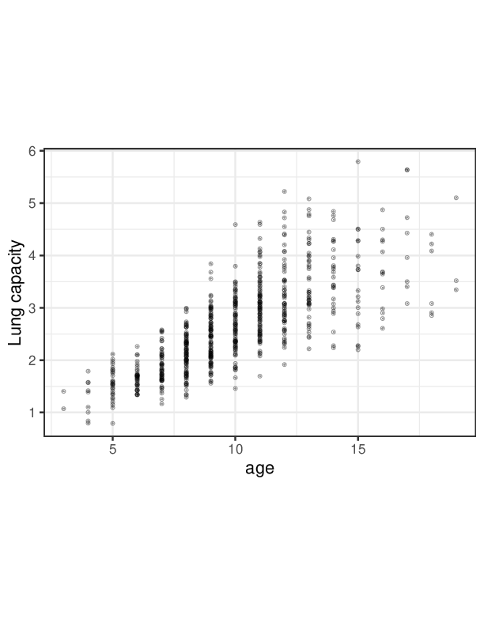

## Seeing the density worse

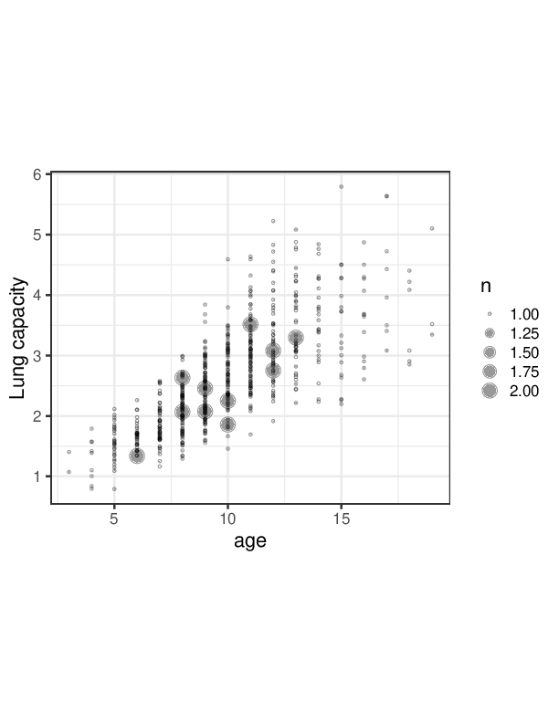

## Maybe fixed

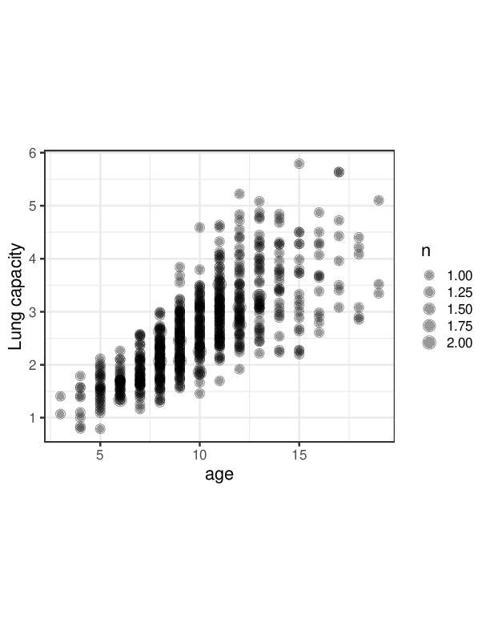

## A loess trend line

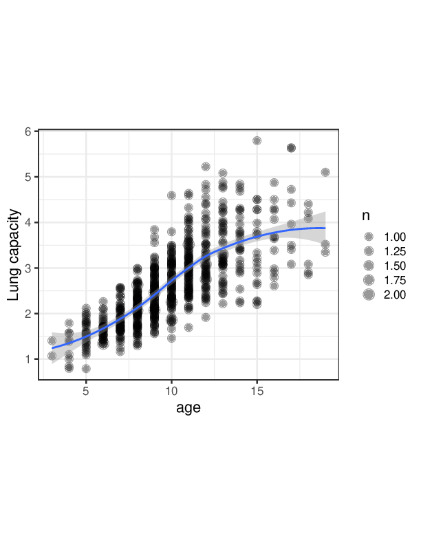

## Two loess trend lines

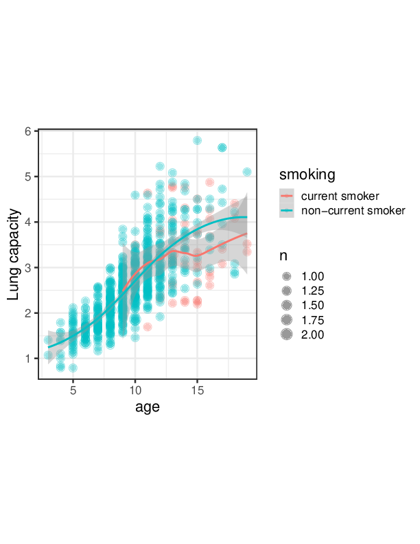

## Many loess trend lines

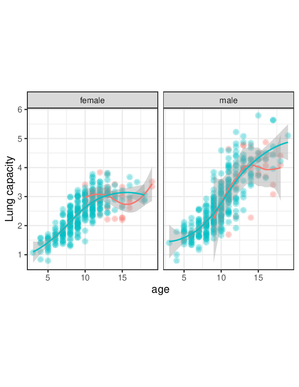

## Robust methods

- Loess is local, but not robust
  - Uses least squares, can respond strongly to outliers

## Density plots

- Contours
  - use to fit a two-dimensional kernel to the density
- hexes
  - use to plot densities using hexes
  - this can also be done using rectangles for data with more discrete values